# Cars93 데이터로 SVM과 인공신경망 모델을 이용해 회귀분석 후 R2와 RMSE을 구하고 비교하세요

- 종속변수 y = Price
- 독립변수 X = price제외

```python
import pandas as pd

df = pd.read_csv('./data/Cars93.csv')
y = df['Price']
X = df.drop(['Min.Price','Price','Max.Price'],axis=1)
```

```python
X.info()
```

```
<class 'pandas.core.frame.DataFrame'>
RangeIndex: 93 entries, 0 to 92
Data columns (total 24 columns):
 #   Column              Non-Null Count  Dtype
---  ------              --------------  -----
 0   Manufacturer        93 non-null     object
 1   Model               93 non-null     object
 2   Type                93 non-null     object
 3   MPG.city            93 non-null     int64
 4   MPG.highway         93 non-null     int64
 5   AirBags             93 non-null     object
 6   DriveTrain          93 non-null     object
 7   Cylinders           93 non-null     object
 8   EngineSize          93 non-null     float64
 9   Horsepower          93 non-null     int64
```

[output cut: 16 more lines]

```python
X.describe()
```

|  | MPG.city | MPG.highway | EngineSize | Horsepower | RPM | Rev.per.mile | Fuel.tank.capacity | Passengers | Length | Wheelbase | Width | Turn.circle | Rear.seat.room | Luggage.room | Weight |
| --- | --- | --- | --- | --- | --- | --- | --- | --- | --- | --- | --- | --- | --- | --- | --- |
| count | 93.000000 | 93.000000 | 93.000000 | 93.000000 | 93.000000 | 93.000000 | 93.000000 | 93.000000 | 93.000000 | 93.000000 | 93.000000 | 93.000000 | 91.000000 | 9.300000e+01 | 93.000000 |
| mean | 22.365591 | 29.086022 | 2.667742 | 143.827957 | 5280.645161 | 2332.204301 | 16.664516 | 5.086022 | 183.204301 | 103.946237 | 69.376344 | 38.956989 | 27.829670 | -2.540034e+08 | 3072.903226 |
| std | 5.619812 | 5.331726 | 1.037363 | 52.374410 | 596.731690 | 496.506525 | 3.279370 | 1.038979 | 14.602382 | 6.819674 | 3.778986 | 3.223265 | 2.989072 | 6.972648e+08 | 589.896510 |
| min | 15.000000 | 20.000000 | 1.000000 | 55.000000 | 3800.000000 | 1320.000000 | 9.200000 | 2.000000 | 141.000000 | 90.000000 | 60.000000 | 32.000000 | 19.000000 | -2.147484e+09 | 1695.000000 |
| 25% | 18.000000 | 26.000000 | 1.800000 | 103.000000 | 4800.000000 | 1985.000000 | 14.500000 | 4.000000 | 174.000000 | 98.000000 | 67.000000 | 37.000000 | 26.000000 | 1.100000e+01 | 2620.000000 |
| 50% | 21.000000 | 28.000000 | 2.400000 | 140.000000 | 5200.000000 | 2340.000000 | 16.400000 | 5.000000 | 183.000000 | 103.000000 | 69.000000 | 39.000000 | 27.500000 | 1.400000e+01 | 3040.000000 |
| 75% | 25.000000 | 31.000000 | 3.300000 | 170.000000 | 5750.000000 | 2565.000000 | 18.800000 | 6.000000 | 192.000000 | 110.000000 | 72.000000 | 41.000000 | 30.000000 | 1.500000e+01 | 3525.000000 |
| max | 46.000000 | 50.000000 | 5.700000 | 300.000000 | 6500.000000 | 3755.000000 | 27.000000 | 8.000000 | 219.000000 | 119.000000 | 78.000000 | 45.000000 | 36.000000 | 2.200000e+01 | 4105.000000 |

## 전처리

### 결측치를 처리하자

mean()으로 처리하되, 0.5단위로 맞추기

```python
X['Rear.seat.room'].fillna(round(X['Rear.seat.room'].mean()*2)/2, inplace=True)
```

### 범주형 변수 전처리

```python
dum_cols = ['Manufacturer','Model','Type','AirBags','DriveTrain','Cylinders','Man.trans.avail','Origin','Make']
X = pd.get_dummies(columns=dum_cols,data=X)
```

### 홀드아웃으로 test train 나누기

```python
from sklearn.model_selection import train_test_split
X_train, X_test, y_train, y_test = train_test_split(X,y,test_size=0.3, random_state=2021)
```

### 정규화 스케일 전처리

```python
from sklearn.preprocessing import StandardScaler
scaler = StandardScaler()
X_train_scaled = pd.DataFrame(scaler.fit_transform(X_train),columns=X_train.columns)
X_test_scaled = pd.DataFrame(scaler.transform(X_test),columns=X_train.columns)
```

## SVR

### SVR 그리드 서치

```python
from sklearn.svm import SVR
from sklearn.model_selection import GridSearchCV

# 테스트하고자 하는 파라미터 값들을 사전타입으로 정의

param_grid = [
    {'kernel': ['linear'], 'C': [10, 30, 100, 300, 1000,10000]},
    {'kernel': ['rbf'], 'C': [1, 3, 10, 30, 100, 300],
                        'gamma': [0.03, 0.1, 0.3, 1.0, 3.0]},
]

grid_svr = GridSearchCV(SVR(), param_grid =param_grid, cv = 5)
grid_svr.fit(X_train_scaled, y_train)

result = pd.DataFrame(grid_svr.cv_results_['params'])
result['mean_test_score'] = grid_svr.cv_results_['mean_test_score']
result.sort_values(by='mean_test_score', ascending=False)
```

|  | C | kernel | gamma | mean_test_score |
| --- | --- | --- | --- | --- |
| 0 | 10 | linear | NaN | 0.611311 |
| 2 | 100 | linear | NaN | 0.611311 |
| 3 | 300 | linear | NaN | 0.611311 |
| 4 | 1000 | linear | NaN | 0.611311 |
| 5 | 10000 | linear | NaN | 0.611311 |
| 1 | 30 | linear | NaN | 0.611311 |
| 16 | 10 | rbf | 0.03 | -0.045560 |
| 17 | 10 | rbf | 0.10 | -0.045898 |
| 20 | 10 | rbf | 3.00 | -0.045898 |
| 19 | 10 | rbf | 1.00 | -0.045898 |
| 18 | 10 | rbf | 0.30 | -0.045898 |
| 6 | 1 | rbf | 0.03 | -0.051981 |
| 7 | 1 | rbf | 0.10 | -0.052019 |
| 10 | 1 | rbf | 3.00 | -0.052019 |
| 9 | 1 | rbf | 1.00 | -0.052019 |
| 8 | 1 | rbf | 0.30 | -0.052019 |
| 21 | 30 | rbf | 0.03 | -0.053555 |
| 22 | 30 | rbf | 0.10 | -0.054017 |
| 25 | 30 | rbf | 3.00 | -0.054017 |
| 24 | 30 | rbf | 1.00 | -0.054017 |
| 23 | 30 | rbf | 0.30 | -0.054017 |
| 31 | 300 | rbf | 0.03 | -0.060194 |
| 26 | 100 | rbf | 0.03 | -0.060194 |
| 32 | 300 | rbf | 0.10 | -0.060679 |
| 27 | 100 | rbf | 0.10 | -0.060679 |
| 29 | 100 | rbf | 1.00 | -0.060679 |
| 33 | 300 | rbf | 0.30 | -0.060679 |
| 34 | 300 | rbf | 1.00 | -0.060679 |
| 30 | 100 | rbf | 3.00 | -0.060679 |
| 35 | 300 | rbf | 3.00 | -0.060679 |
| 28 | 100 | rbf | 0.30 | -0.060679 |
| 11 | 3 | rbf | 0.03 | -0.061360 |
| 12 | 3 | rbf | 0.10 | -0.061478 |
| 15 | 3 | rbf | 3.00 | -0.061478 |
| 14 | 3 | rbf | 1.00 | -0.061478 |
| 13 | 3 | rbf | 0.30 | -0.061478 |

```python
from sklearn.svm import SVR
import numpy as np
from sklearn.model_selection import GridSearchCV

# 테스트하고자 하는 파라미터 값들을 사전타입으로 정의

param_grid = [
    {'kernel': ['linear'], 'C': np.arange(0.1,10,0.05)}
]

grid_svr = GridSearchCV(SVR(), param_grid =param_grid, cv = 5)
grid_svr.fit(X_train_scaled, y_train)

result = pd.DataFrame(grid_svr.cv_results_['params'])
result['mean_test_score'] = grid_svr.cv_results_['mean_test_score']
result.sort_values(by='mean_test_score', ascending=False).head(20)
```

|  | C | kernel | mean_test_score |
| --- | --- | --- | --- |
| 99 | 5.05 | linear | 0.611311 |
| 125 | 6.35 | linear | 0.611311 |
| 127 | 6.45 | linear | 0.611311 |
| 128 | 6.50 | linear | 0.611311 |
| 129 | 6.55 | linear | 0.611311 |
| 130 | 6.60 | linear | 0.611311 |
| 131 | 6.65 | linear | 0.611311 |
| 132 | 6.70 | linear | 0.611311 |
| 133 | 6.75 | linear | 0.611311 |
| 134 | 6.80 | linear | 0.611311 |
| 135 | 6.85 | linear | 0.611311 |
| 136 | 6.90 | linear | 0.611311 |
| 137 | 6.95 | linear | 0.611311 |
| 138 | 7.00 | linear | 0.611311 |
| 139 | 7.05 | linear | 0.611311 |
| 140 | 7.10 | linear | 0.611311 |
| 141 | 7.15 | linear | 0.611311 |
| 142 | 7.20 | linear | 0.611311 |
| 143 | 7.25 | linear | 0.611311 |
| 144 | 7.30 | linear | 0.611311 |

```python
grid_svr.best_estimator_.get_params()
```

```
{'C': 0.20000000000000004,
 'cache_size': 200,
 'coef0': 0.0,
 'degree': 3,
 'epsilon': 0.1,
 'gamma': 'scale',
 'kernel': 'linear',
 'max_iter': -1,
 'shrinking': True,
 'tol': 0.001,
 'verbose': False}
```

```python
from sklearn.metrics import mean_squared_error
import numpy as np

print("train data R2 : ",grid_svr.best_estimator_.score(X_train_scaled,y_train))
print("test data R2 : ",grid_svr.best_estimator_.score(X_test_scaled,y_test))
print("RMSE : ", np.sqrt(mean_squared_error(y_test,grid_svr.best_estimator_.predict(X_test_scaled))))
```

```
train data R2 :  0.9999042027220784
test data R2 :  0.7081119646866254
RMSE :  4.207243116664975
```

## 인공신경망 회귀

```python
from sklearn.neural_network import MLPRegressor

mlpr = MLPRegressor(hidden_layer_sizes=(64,64,64,64,64), activation='relu', max_iter = 1000, random_state=2021)
mlpr.fit(X_train_scaled, y_train)

print("train data R2 : ",mlpr.score(X_train_scaled, y_train))
print("test data R2 : ",mlpr.score(X_test_scaled,y_test))
```

```
train data R2 :  0.9999990566608916
test data R2 :  0.3266369260721378
```

```python
mlpr.get_params()
```

```
{'activation': 'relu',
 'alpha': 0.0001,
 'batch_size': 'auto',
 'beta_1': 0.9,
 'beta_2': 0.999,
 'early_stopping': False,
 'epsilon': 1e-08,
 'hidden_layer_sizes': (64, 64, 64, 64, 64),
 'learning_rate': 'constant',
 'learning_rate_init': 0.001,
 'max_fun': 15000,
 'max_iter': 1000,
 'momentum': 0.9,
 'n_iter_no_change': 10,
 'nesterovs_momentum': True,
 'power_t': 0.5,
 'random_state': 2021,
 'shuffle': True,
 'solver': 'adam',
 'tol': 0.0001,
 'validation_fraction': 0.1,
 'verbose': False,
 'warm_start': False}
```

```python
from sklearn.model_selection import GridSearchCV

# 테스트하고자 하는 파라미터 값들을 사전타입으로 정의

parameters = {'hidden_layer_sizes':[30,50,100,(64,64,64,64,64),(16,16,16,16,16,16,16)] ,
              'solver': ['sgd', 'lbfgs'],
              'activation' : ['tanh','relu'],
             'max_iter' : [1000],
             'alpha':[0.0001, 0.001, 0.0001]}

grid_mlp = GridSearchCV(MLPRegressor(), param_grid = parameters, cv = 5)
grid_mlp.fit(X_train_scaled, y_train)

result = pd.DataFrame(grid_mlp.cv_results_['params'])
result['mean_test_score'] = grid_mlp.cv_results_['mean_test_score']
result.sort_values(by='mean_test_score', ascending=False)
```

[output not shown]

|  | activation | alpha | hidden_layer_sizes | max_iter | solver | mean_test_score |
| --- | --- | --- | --- | --- | --- | --- |
| 58 | relu | 0.0001 | (16, 16, 16, 16, 16, 16, 16) | 1000 | sgd | 0.373160 |
| 56 | relu | 0.0001 | (64, 64, 64, 64, 64) | 1000 | sgd | 0.373035 |
| 36 | relu | 0.0001 | (64, 64, 64, 64, 64) | 1000 | sgd | 0.342809 |
| 49 | relu | 0.0010 | (16, 16, 16, 16, 16, 16, 16) | 1000 | lbfgs | 0.333040 |
| 44 | relu | 0.0010 | 100 | 1000 | sgd | 0.323057 |
| 37 | relu | 0.0001 | (64, 64, 64, 64, 64) | 1000 | lbfgs | 0.302477 |
| 59 | relu | 0.0001 | (16, 16, 16, 16, 16, 16, 16) | 1000 | lbfgs | 0.301241 |
| 47 | relu | 0.0010 | (64, 64, 64, 64, 64) | 1000 | lbfgs | 0.266962 |
| 57 | relu | 0.0001 | (64, 64, 64, 64, 64) | 1000 | lbfgs | 0.263341 |
| 54 | relu | 0.0001 | 100 | 1000 | sgd | 0.253912 |
| 48 | relu | 0.0010 | (16, 16, 16, 16, 16, 16, 16) | 1000 | sgd | 0.213181 |
| 39 | relu | 0.0001 | (16, 16, 16, 16, 16, 16, 16) | 1000 | lbfgs | 0.211217 |
| 34 | relu | 0.0001 | 100 | 1000 | sgd | 0.196232 |
| 7 | tanh | 0.0001 | (64, 64, 64, 64, 64) | 1000 | lbfgs | 0.104464 |
| 46 | relu | 0.0010 | (64, 64, 64, 64, 64) | 1000 | sgd | 0.039324 |
| 38 | relu | 0.0001 | (16, 16, 16, 16, 16, 16, 16) | 1000 | sgd | 0.029876 |
| 55 | relu | 0.0001 | 100 | 1000 | lbfgs | -0.050598 |
| 45 | relu | 0.0010 | 100 | 1000 | lbfgs | -0.081649 |
| 16 | tanh | 0.0010 | (64, 64, 64, 64, 64) | 1000 | sgd | -0.122114 |
| 18 | tanh | 0.0010 | (16, 16, 16, 16, 16, 16, 16) | 1000 | sgd | -0.132724 |
| 35 | relu | 0.0001 | 100 | 1000 | lbfgs | -0.199852 |
| 8 | tanh | 0.0001 | (16, 16, 16, 16, 16, 16, 16) | 1000 | sgd | -0.202051 |
| 28 | tanh | 0.0001 | (16, 16, 16, 16, 16, 16, 16) | 1000 | sgd | -0.231757 |
| 32 | relu | 0.0001 | 50 | 1000 | sgd | -0.241970 |
| 42 | relu | 0.0010 | 50 | 1000 | sgd | -0.260853 |
| 52 | relu | 0.0001 | 50 | 1000 | sgd | -0.354305 |
| 43 | relu | 0.0010 | 50 | 1000 | lbfgs | -0.379635 |
| 19 | tanh | 0.0010 | (16, 16, 16, 16, 16, 16, 16) | 1000 | lbfgs | -0.486362 |
| 29 | tanh | 0.0001 | (16, 16, 16, 16, 16, 16, 16) | 1000 | lbfgs | -0.510684 |
| 33 | relu | 0.0001 | 50 | 1000 | lbfgs | -0.511796 |
| 27 | tanh | 0.0001 | (64, 64, 64, 64, 64) | 1000 | lbfgs | -0.561166 |
| 53 | relu | 0.0001 | 50 | 1000 | lbfgs | -0.564178 |
| 31 | relu | 0.0001 | 30 | 1000 | lbfgs | -0.568676 |
| 17 | tanh | 0.0010 | (64, 64, 64, 64, 64) | 1000 | lbfgs | -0.641752 |
| 30 | relu | 0.0001 | 30 | 1000 | sgd | -0.644293 |
| 51 | relu | 0.0001 | 30 | 1000 | lbfgs | -0.698635 |
| 6 | tanh | 0.0001 | (64, 64, 64, 64, 64) | 1000 | sgd | -0.718903 |
| 40 | relu | 0.0010 | 30 | 1000 | sgd | -0.805402 |
| 50 | relu | 0.0001 | 30 | 1000 | sgd | -0.825607 |
| 41 | relu | 0.0010 | 30 | 1000 | lbfgs | -0.862090 |
| 9 | tanh | 0.0001 | (16, 16, 16, 16, 16, 16, 16) | 1000 | lbfgs | -0.946264 |
| 26 | tanh | 0.0001 | (64, 64, 64, 64, 64) | 1000 | sgd | -1.470972 |
| 11 | tanh | 0.0010 | 30 | 1000 | lbfgs | -6.937461 |
| 13 | tanh | 0.0010 | 50 | 1000 | lbfgs | -7.068843 |
| 21 | tanh | 0.0001 | 30 | 1000 | lbfgs | -9.421066 |
| 1 | tanh | 0.0001 | 30 | 1000 | lbfgs | -9.563706 |
| 25 | tanh | 0.0001 | 100 | 1000 | lbfgs | -11.469200 |
| 23 | tanh | 0.0001 | 50 | 1000 | lbfgs | -11.589373 |
| 3 | tanh | 0.0001 | 50 | 1000 | lbfgs | -11.768637 |
| 15 | tanh | 0.0010 | 100 | 1000 | lbfgs | -13.593863 |
| 4 | tanh | 0.0001 | 100 | 1000 | sgd | -13.700864 |
| 14 | tanh | 0.0010 | 100 | 1000 | sgd | -13.788864 |
| 24 | tanh | 0.0001 | 100 | 1000 | sgd | -14.332661 |
| 12 | tanh | 0.0010 | 50 | 1000 | sgd | -14.360015 |
| 2 | tanh | 0.0001 | 50 | 1000 | sgd | -14.920369 |
| 22 | tanh | 0.0001 | 50 | 1000 | sgd | -14.990285 |
| 5 | tanh | 0.0001 | 100 | 1000 | lbfgs | -15.018356 |
| 10 | tanh | 0.0010 | 30 | 1000 | sgd | -15.146228 |
| 20 | tanh | 0.0001 | 30 | 1000 | sgd | -16.153062 |
| 0 | tanh | 0.0001 | 30 | 1000 | sgd | -16.512376 |

```python
grid_mlp.best_estimator_.get_params()
```

```
{'activation': 'relu',
 'alpha': 0.0001,
 'batch_size': 'auto',
 'beta_1': 0.9,
 'beta_2': 0.999,
 'early_stopping': False,
 'epsilon': 1e-08,
 'hidden_layer_sizes': (16, 16, 16, 16, 16, 16, 16),
 'learning_rate': 'constant',
 'learning_rate_init': 0.001,
 'max_fun': 15000,
 'max_iter': 1000,
 'momentum': 0.9,
 'n_iter_no_change': 10,
 'nesterovs_momentum': True,
 'power_t': 0.5,
 'random_state': None,
 'shuffle': True,
 'solver': 'sgd',
 'tol': 0.0001,
 'validation_fraction': 0.1,
 'verbose': False,
 'warm_start': False}
```

```python
print("SVR train data R2 : ",grid_svr.best_estimator_.score(X_train_scaled,y_train))
print("SVR test data R2 : ",grid_svr.best_estimator_.score(X_test_scaled,y_test))
print("SVR RMSE : ", np.sqrt(mean_squared_error(y_test,grid_svr.best_estimator_.predict(X_test_scaled))))

print("인공신경망 train data R2 : ",grid_mlp.best_estimator_.score(X_train_scaled,y_train))
print("인공신경망 test data R2 : ",grid_mlp.best_estimator_.score(X_test_scaled,y_test))
print("인공신경망 RMSE : ", np.sqrt(mean_squared_error(y_test,grid_mlp.best_estimator_.predict(X_test_scaled))))
```

```
SVR train data R2 :  0.9999042027220784
SVR test data R2 :  0.7081119646866254
SVR RMSE :  4.207243116664975
인공신경망 train data R2 :  0.9999125970107646
인공신경망 test data R2 :  0.5710092956569901
인공신경망 RMSE :  5.100507643806167
```

- SVR params: 'C': 0.2, 'kernel': 'linear'
- 인공신경망 회귀 params: 'activation': 'relu', 'alpha': 0.0001, 'hidden_layer_sizes': (16, 16, 16, 16, 16, 16, 16)
- 인공신경망 회귀 모델의 경우, train R2 에 비해 test 데이터에 대하여 R2 점수가 많이 떨어지는 것으로 보아 train 데이터 세트에 대해 과적합 된 경향이 크다고 할 수 있다.
- SVR의 test data R2: **0.71** 로 인공신경망보다 설명률이 높다.
- SVR의 RMSE: **4.21** 로 인공신경망보다 낮다.
- 따라서 도출된 **SVR** 의 모델이 인공신경망 회귀 모델보다 성능이 좋다고 할 수 있다.

# titanic 데이터로 나이브베이즈 , SVM, 인공신경망, KNN 모델을 이용해 분류분석 후 최적의 모델을 선정하고 그 이유를 작성하세요.

```python
import pandas as pd

df_t = pd.read_csv('./data/titanic.csv')
y = df_t['survived']
X = df_t.drop(['survived'],axis=1)
```

```python
X.info()
```

```
<class 'pandas.core.frame.DataFrame'>
RangeIndex: 891 entries, 0 to 890
Data columns (total 10 columns):
 #   Column       Non-Null Count  Dtype
---  ------       --------------  -----
 0   pclass       891 non-null    int64
 1   sex          891 non-null    object
 2   age          714 non-null    float64
 3   sibsp        891 non-null    int64
 4   parch        891 non-null    int64
 5   fare         891 non-null    float64
 6   embarked     889 non-null    object
 7   class        891 non-null    object
 8   adult_male   891 non-null    bool
 9   embark_town  889 non-null    object
dtypes: bool(1), float64(2), int64(3), object(4)
memory usage: 63.6+ KB
```

```python
X.drop(columns=['pclass','embarked'], inplace=True)
```

```python
X.info()
```

```
<class 'pandas.core.frame.DataFrame'>
RangeIndex: 891 entries, 0 to 890
Data columns (total 8 columns):
 #   Column       Non-Null Count  Dtype
---  ------       --------------  -----
 0   sex          891 non-null    object
 1   age          714 non-null    float64
 2   sibsp        891 non-null    int64
 3   parch        891 non-null    int64
 4   fare         891 non-null    float64
 5   class        891 non-null    object
 6   adult_male   891 non-null    bool
 7   embark_town  889 non-null    object
dtypes: bool(1), float64(2), int64(2), object(3)
memory usage: 49.7+ KB
```

```python
X['fare'].value_counts()
```

```
8.0500     43
13.0000    42
7.8958     38
7.7500     34
26.0000    31
           ..
50.4958     1
13.8583     1
8.4583      1
7.7250      1
7.5208      1
Name: fare, Length: 248, dtype: int64
```

```python
X['class'].value_counts()
```

```
Third     491
First     216
Second    184
Name: class, dtype: int64
```

## 전처리

### 결측치 처리

```python
X.describe()
```

|  | age | sibsp | parch | fare |
| --- | --- | --- | --- | --- |
| count | 714.000000 | 891.000000 | 891.000000 | 891.000000 |
| mean | 29.699118 | 0.523008 | 0.381594 | 32.204208 |
| std | 14.526497 | 1.102743 | 0.806057 | 49.693429 |
| min | 0.420000 | 0.000000 | 0.000000 | 0.000000 |
| 25% | 20.125000 | 0.000000 | 0.000000 | 7.910400 |
| 50% | 28.000000 | 0.000000 | 0.000000 | 14.454200 |
| 75% | 38.000000 | 1.000000 | 0.000000 | 31.000000 |
| max | 80.000000 | 8.000000 | 6.000000 | 512.329200 |

```python
X['age'].fillna(X['age'].mean(), inplace=True)
X['embark_town'].fillna(X['embark_town'].describe().top, inplace=True)
X.info()
```

```
<class 'pandas.core.frame.DataFrame'>
RangeIndex: 891 entries, 0 to 890
Data columns (total 8 columns):
 #   Column       Non-Null Count  Dtype
---  ------       --------------  -----
 0   sex          891 non-null    object
 1   age          891 non-null    float64
 2   sibsp        891 non-null    int64
 3   parch        891 non-null    int64
 4   fare         891 non-null    float64
 5   class        891 non-null    object
 6   adult_male   891 non-null    bool
 7   embark_town  891 non-null    object
dtypes: bool(1), float64(2), int64(2), object(3)
memory usage: 49.7+ KB
```

### 범주형 변수 전처리

```python
X = pd.get_dummies(columns=['sex','class','embark_town'],data=X)
```

### test train split

```python
from sklearn.model_selection import train_test_split
X_train, X_test, y_train, y_test = train_test_split(X,y,test_size=0.3, random_state=2021)
```

### 정규화 스케일 전처리

```python
from sklearn.preprocessing import StandardScaler
scaler = StandardScaler()
X_train_scaled = pd.DataFrame(scaler.fit_transform(X_train),columns=X_train.columns)
X_test_scaled = pd.DataFrame(scaler.transform(X_test),columns=X_train.columns)
```

```python
X_train_scaled
```

|  | age | sibsp | parch | fare | adult_male | sex_female | sex_male | class_First | class_Second | class_Third | embark_town_Cherbourg | embark_town_Queenstown | embark_town_Southampton |
| --- | --- | --- | --- | --- | --- | --- | --- | --- | --- | --- | --- | --- | --- |
| 0 | -0.727095 | -0.486659 | -0.496159 | -0.483094 | 0.821420 | -0.736260 | 0.736260 | -0.575497 | -0.518497 | 0.924211 | -0.485913 | -0.295398 | 0.610120 |
| 1 | 1.515652 | 0.382076 | -0.496159 | 0.865151 | -1.217404 | 1.358215 | -1.358215 | 1.737629 | -0.518497 | -1.082004 | 2.057983 | -0.295398 | -1.639021 |
| 2 | -0.108406 | -0.486659 | -0.496159 | -0.446697 | 0.821420 | -0.736260 | 0.736260 | -0.575497 | 1.928652 | -1.082004 | -0.485913 | -0.295398 | 0.610120 |
| 3 | 0.510283 | -0.486659 | -0.496159 | -0.397178 | 0.821420 | -0.736260 | 0.736260 | -0.575497 | 1.928652 | -1.082004 | -0.485913 | -0.295398 | 0.610120 |
| 4 | 0.510283 | 0.382076 | 1.957072 | -0.105014 | 0.821420 | -0.736260 | 0.736260 | -0.575497 | 1.928652 | -1.082004 | -0.485913 | -0.295398 | 0.610120 |
| ... | ... | ... | ... | ... | ... | ... | ... | ... | ... | ... | ... | ... | ... |
| 618 | 0.974300 | 0.382076 | -0.496159 | 0.386300 | 0.821420 | -0.736260 | 0.736260 | 1.737629 | -0.518497 | -1.082004 | -0.485913 | -0.295398 | 0.610120 |
| 619 | 0.022997 | 0.382076 | 0.730457 | -0.211812 | -1.217404 | 1.358215 | -1.358215 | -0.575497 | -0.518497 | 0.924211 | 2.057983 | -0.295398 | -1.639021 |
| 620 | -0.069738 | -0.486659 | -0.496159 | -0.511484 | 0.821420 | -0.736260 | 0.736260 | -0.575497 | -0.518497 | 0.924211 | 2.057983 | -0.295398 | -1.639021 |
| 621 | -0.417751 | 2.119546 | 1.957072 | 4.554748 | -1.217404 | 1.358215 | -1.358215 | 1.737629 | -0.518497 | -1.082004 | -0.485913 | -0.295398 | 0.610120 |
| 622 | 3.178379 | -0.486659 | -0.496159 | -0.501169 | 0.821420 | -0.736260 | 0.736260 | -0.575497 | -0.518497 | 0.924211 | -0.485913 | 3.385262 | -1.639021 |

623 rows × 13 columns

## 나이브베이즈 분류

### 멀티노미얼 분류를 쓰자

```python
from sklearn.naive_bayes import MultinomialNB
import numpy as np

clf = MultinomialNB()
clf.fit(X_train, y_train)
y_pred_clf = clf.predict(X_test)
```

```python
from sklearn.metrics import accuracy_score, precision_score, recall_score, f1_score, plot_roc_curve, roc_auc_score
from sklearn.metrics import confusion_matrix

print(f"정확도 : {accuracy_score(y_test, y_pred_clf)}")
print(f"정밀도 : {precision_score(y_test, y_pred_clf)}")
print(f"재현율 : {recall_score(y_test, y_pred_clf)}")
print(f"F1 스코어 : {f1_score(y_test, y_pred_clf)}")
print(f"ROC_AUC_SCORE : {roc_auc_score(y_test, y_pred_clf)}")

pd.DataFrame(confusion_matrix(y_test, y_pred_clf),
             index=['True[0]', 'True[1]'],
             columns=['Pred[0]','Pred[1]'])
```

```
정확도 : 0.6902985074626866
정밀도 : 0.6428571428571429
재현율 : 0.4368932038834951
F1 스코어 : 0.5202312138728323
ROC_AUC_SCORE : 0.6426890261841718
```

|  | Pred[0] | Pred[1] |
| --- | --- | --- |
| True[0] | 140 | 25 |
| True[1] | 58 | 45 |

## SVC

```python
from sklearn.svm import SVC

svc = SVC()
svc = svc.fit(X_train_scaled, y_train)
#y_pred_svc = svc.predict(X_test_scaled)
```

```python
parameters = [
    {'kernel': ['linear'], 'C': [10, 30, 100, 300, 1000,10000]},
    {'kernel': ['rbf'], 'C': [1, 3, 10, 30, 100, 300],
                        'gamma': [0.03, 0.1, 0.3, 1.0, 3.0]},
]
#parameters = {'gamma':[0.1, 1, 10] ,'C': [0.01, 0.1 ,0.5, 1, 10,20,30]}
```

```python
from sklearn.model_selection import GridSearchCV

# 테스트하고자 하는 파라미터 값들을 사전타입으로 정의

parameters = {'gamma':[0.01, 0.05, 0.1, 1, 10] ,'C': [0.01, 0.1 ,0.5, 1, 3, 5, 10,20,30]}

grid_svc = GridSearchCV(SVC(), param_grid = parameters, cv = 5, scoring='f1')
grid_svc.fit(X_train_scaled, y_train)

result = pd.DataFrame(grid_svc.cv_results_['params'])
result['mean_test_score'] = grid_svc.cv_results_['mean_test_score']
result.sort_values(by='mean_test_score', ascending=False)

#y_pred_svc = grid_svc.best_estimator_.predict(X_test_scaled)
```

|  | C | gamma | mean_test_score |
| --- | --- | --- | --- |
| 25 | 5.00 | 0.01 | 0.776053 |
| 20 | 3.00 | 0.01 | 0.774205 |
| 21 | 3.00 | 0.05 | 0.763871 |
| 17 | 1.00 | 0.10 | 0.762757 |
| 35 | 20.00 | 0.01 | 0.762585 |
| 16 | 1.00 | 0.05 | 0.759871 |
| 40 | 30.00 | 0.01 | 0.759647 |
| 30 | 10.00 | 0.01 | 0.759623 |
| 11 | 0.50 | 0.05 | 0.759055 |
| 22 | 3.00 | 0.10 | 0.757667 |
| 27 | 5.00 | 0.10 | 0.755774 |
| 12 | 0.50 | 0.10 | 0.754507 |
| 31 | 10.00 | 0.05 | 0.752791 |
| 32 | 10.00 | 0.10 | 0.751293 |
| 26 | 5.00 | 0.05 | 0.751036 |
| 36 | 20.00 | 0.05 | 0.748295 |
| 41 | 30.00 | 0.05 | 0.748295 |
| 15 | 1.00 | 0.01 | 0.748159 |
| 37 | 20.00 | 0.10 | 0.743632 |
| 6 | 0.10 | 0.05 | 0.740548 |
| 7 | 0.10 | 0.10 | 0.738294 |
| 18 | 1.00 | 1.00 | 0.738157 |
| 42 | 30.00 | 0.10 | 0.734627 |
| 33 | 10.00 | 1.00 | 0.733333 |
| 13 | 0.50 | 1.00 | 0.731561 |
| 28 | 5.00 | 1.00 | 0.727801 |
| 23 | 3.00 | 1.00 | 0.727036 |
| 43 | 30.00 | 1.00 | 0.722536 |
| 5 | 0.10 | 0.01 | 0.721408 |
| 10 | 0.50 | 0.01 | 0.718043 |
| 38 | 20.00 | 1.00 | 0.716422 |
| 19 | 1.00 | 10.00 | 0.707101 |
| 24 | 3.00 | 10.00 | 0.698463 |
| 29 | 5.00 | 10.00 | 0.695797 |
| 34 | 10.00 | 10.00 | 0.695797 |
| 39 | 20.00 | 10.00 | 0.691879 |
| 44 | 30.00 | 10.00 | 0.689278 |
| 14 | 0.50 | 10.00 | 0.432798 |
| 8 | 0.10 | 1.00 | 0.181907 |
| 1 | 0.01 | 0.05 | 0.000000 |
| 9 | 0.10 | 10.00 | 0.000000 |
| 4 | 0.01 | 10.00 | 0.000000 |
| 3 | 0.01 | 1.00 | 0.000000 |
| 2 | 0.01 | 0.10 | 0.000000 |
| 0 | 0.01 | 0.01 | 0.000000 |

```python
grid_svc.best_estimator_.get_params()
```

```
{'C': 5,
 'break_ties': False,
 'cache_size': 200,
 'class_weight': None,
 'coef0': 0.0,
 'decision_function_shape': 'ovr',
 'degree': 3,
 'gamma': 0.01,
 'kernel': 'rbf',
 'max_iter': -1,
 'probability': False,
 'random_state': None,
 'shrinking': True,
 'tol': 0.001,
 'verbose': False}
```

```python
y_pred_svc = grid_svc.best_estimator_.predict(X_test_scaled)
y_pred_svc
```

```
array([0, 0, 0, 0, 0, 1, 1, 0, 0, 0, 0, 0, 0, 0, 1, 1, 0, 0, 0, 1, 0, 0,
       1, 1, 0, 0, 0, 0, 1, 0, 1, 0, 0, 0, 0, 1, 0, 0, 0, 1, 1, 0, 1, 0,
       0, 0, 0, 1, 0, 0, 1, 1, 1, 1, 1, 0, 0, 1, 1, 1, 0, 0, 1, 1, 0, 0,
       0, 1, 0, 0, 1, 1, 0, 1, 0, 0, 1, 0, 0, 1, 0, 0, 0, 0, 0, 0, 0, 1,
       0, 0, 0, 0, 1, 0, 0, 1, 0, 1, 0, 1, 0, 0, 1, 0, 1, 0, 0, 0, 0, 0,
       0, 0, 0, 0, 0, 0, 0, 0, 1, 0, 1, 0, 0, 1, 0, 1, 1, 1, 0, 1, 0, 0,
       0, 1, 1, 0, 0, 1, 1, 1, 0, 0, 1, 0, 0, 0, 0, 0, 0, 1, 0, 1, 0, 0,
       0, 0, 0, 0, 0, 0, 0, 1, 0, 1, 1, 0, 0, 1, 0, 0, 0, 1, 1, 1, 0, 1,
       1, 0, 0, 0, 0, 1, 1, 0, 1, 0, 0, 0, 1, 0, 0, 0, 0, 1, 0, 0, 0, 0,
       1, 0, 1, 1, 1, 1, 0, 1, 1, 0, 1, 1, 0, 0, 1, 1, 0, 0, 0, 0, 0, 0,
       0, 0, 0, 0, 0, 1, 0, 0, 0, 0, 0, 1, 0, 1, 0, 1, 0, 1, 1, 0, 0, 1,
       0, 0, 1, 0, 1, 0, 0, 0, 0, 0, 1, 1, 0, 1, 1, 0, 0, 0, 1, 1, 0, 0,
       1, 0, 1, 0])
```

```python
from sklearn.metrics import accuracy_score, precision_score, recall_score, f1_score, plot_roc_curve, roc_auc_score
from sklearn.metrics import confusion_matrix

print(f"정확도 : {accuracy_score(y_test, y_pred_svc)}")
print(f"정밀도 : {precision_score(y_test, y_pred_svc)}")
print(f"재현율 : {recall_score(y_test, y_pred_svc)}")
print(f"F1 스코어 : {f1_score(y_test, y_pred_svc)}")
print(f"ROC_AUC_SCORE : {roc_auc_score(y_test, y_pred_svc)}")

pd.DataFrame(confusion_matrix(y_test, y_pred_svc),
             index=['True[0]', 'True[1]'],
             columns=['Pred[0]','Pred[1]'])
```

```
정확도 : 0.8097014925373134
정밀도 : 0.776595744680851
재현율 : 0.7087378640776699
F1 스코어 : 0.7411167512690355
ROC_AUC_SCORE : 0.7907325684024714
```

|  | Pred[0] | Pred[1] |
| --- | --- | --- |
| True[0] | 144 | 21 |
| True[1] | 30 | 73 |

## 인공신경망 분류

```python
from sklearn.model_selection import GridSearchCV
from sklearn.neural_network import MLPClassifier

# 테스트하고자 하는 파라미터 값들을 사전타입으로 정의

parameters = {'hidden_layer_sizes':[10,30,50,100] ,
              'solver': ['sgd', 'adam'],
              'activation' : ['tanh','relu'],
             'max_iter' : [1000]}

grid_mlpc = GridSearchCV(MLPClassifier(), param_grid = parameters, cv = 5, scoring='f1')
grid_mlpc.fit(X_train_scaled, y_train)

result = pd.DataFrame(grid_mlpc.cv_results_['params'])
result['mean_test_score'] = grid_mlpc.cv_results_['mean_test_score']
result.sort_values(by='mean_test_score', ascending=False)
```

|  | activation | hidden_layer_sizes | max_iter | solver | mean_test_score |
| --- | --- | --- | --- | --- | --- |
| 12 | relu | 50 | 1000 | sgd | 0.882997 |
| 14 | relu | 100 | 1000 | sgd | 0.882774 |
| 4 | tanh | 50 | 1000 | sgd | 0.872960 |
| 10 | relu | 30 | 1000 | sgd | 0.872198 |
| 9 | relu | 10 | 1000 | adam | 0.871211 |
| 6 | tanh | 100 | 1000 | sgd | 0.870691 |
| 0 | tanh | 10 | 1000 | sgd | 0.868983 |
| 1 | tanh | 10 | 1000 | adam | 0.866999 |
| 11 | relu | 30 | 1000 | adam | 0.866237 |
| 2 | tanh | 30 | 1000 | sgd | 0.865196 |
| 8 | relu | 10 | 1000 | sgd | 0.862802 |
| 13 | relu | 50 | 1000 | adam | 0.862740 |
| 5 | tanh | 50 | 1000 | adam | 0.859273 |
| 3 | tanh | 30 | 1000 | adam | 0.857482 |
| 15 | relu | 100 | 1000 | adam | 0.854821 |
| 7 | tanh | 100 | 1000 | adam | 0.853425 |

```python
y_pred_mlpc = grid_mlpc.best_estimator_.predict(X_test_scaled)
```

```python
from sklearn.metrics import accuracy_score, precision_score, recall_score, f1_score, plot_roc_curve, roc_auc_score
from sklearn.metrics import confusion_matrix

print(f"정확도 : {accuracy_score(y_test, y_pred_mlpc)}")
print(f"정밀도 : {precision_score(y_test, y_pred_mlpc)}")
print(f"재현율 : {recall_score(y_test, y_pred_mlpc)}")
print(f"F1 스코어 : {f1_score(y_test, y_pred_mlpc)}")
print(f"ROC_AUC_SCORE : {roc_auc_score(y_test, y_pred_mlpc)}")

pd.DataFrame(confusion_matrix(y_test, y_pred_mlpc),
             index=['True[0]', 'True[1]'],
             columns=['Pred[0]','Pred[1]'])
```

```
정확도 : 0.7985074626865671
정밀도 : 0.7634408602150538
재현율 : 0.6893203883495146
F1 스코어 : 0.7244897959183674
ROC_AUC_SCORE : 0.7779935275080907
```

|  | Pred[0] | Pred[1] |
| --- | --- | --- |
| True[0] | 143 | 22 |
| True[1] | 32 | 71 |

## KNN

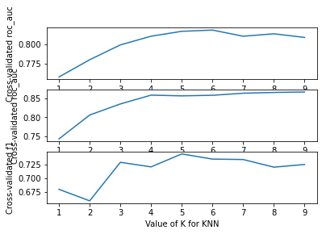

```python
from sklearn.neighbors import KNeighborsClassifier
from sklearn.model_selection import cross_val_score

k_range = range(1,10)
k_scores= []

for k in k_range:
    knn=KNeighborsClassifier(k)
    scores=cross_val_score(knn,X_train_scaled,y_train,cv=10,scoring="accuracy")
    k_scores.append(scores.mean())
import matplotlib.pyplot as plt
plt.subplot(3,1,1)
plt.plot(k_range, k_scores)
plt.xlabel('Value of K for KNN')
plt.ylabel('Cross-validated accuracy')
k_scores= []

for k in k_range:
    knn=KNeighborsClassifier(k)
    scores=cross_val_score(knn,X_train_scaled,y_train,cv=10,scoring="roc_auc")
    k_scores.append(scores.mean())
import matplotlib.pyplot as plt
plt.subplot(3,1,2)
plt.plot(k_range, k_scores)
plt.xlabel('Value of K for KNN')
plt.ylabel('Cross-validated roc_auc')

k_scores= []

for k in k_range:
    knn=KNeighborsClassifier(k)
    scores=cross_val_score(knn,X_train_scaled,y_train,cv=10,scoring="f1")
    k_scores.append(scores.mean())
import matplotlib.pyplot as plt
plt.subplot(3,1,3)
plt.plot(k_range, k_scores)
plt.xlabel('Value of K for KNN')
plt.ylabel('Cross-validated f1')
plt.show()
```

- 이웃하는 개수, 매개변수 k를 늘려감에 따라, AUC_ROC_SCORE와 f1_score 추이를 비교해봤을 때, 3~6사이가 적당해 보인다.
- k=5로 정하자

```python
knn_clf =KNeighborsClassifier(5) #### k = 5
knn_clf.fit(X_train_scaled,y_train)
y_pred_knn_clf = knn_clf.predict(X_test_scaled)

print(f"정확도 : {accuracy_score(y_test, y_pred_knn_clf)}")
print(f"정밀도 : {precision_score(y_test, y_pred_knn_clf)}")
print(f"재현율 : {recall_score(y_test, y_pred_knn_clf)}")
print(f"F1 스코어 : {f1_score(y_test, y_pred_knn_clf)}")
print(f"ROC_AUC_SCORE : {roc_auc_score(y_test, y_pred_knn_clf)}")

pd.DataFrame(confusion_matrix(y_test, y_pred_knn_clf),
             index=['True[0]', 'True[1]'],
             columns=['Pred[0]','Pred[1]'])
```

```
정확도 : 0.7798507462686567
정밀도 : 0.75
재현율 : 0.6407766990291263
F1 스코어 : 0.6910994764397905
ROC_AUC_SCORE : 0.7537216828478965
```

|  | Pred[0] | Pred[1] |
| --- | --- | --- |
| True[0] | 143 | 22 |
| True[1] | 37 | 66 |

```python
print(f"나이브베이즈 정확도 : {accuracy_score(y_test, y_pred_clf)}")
print(f"나이브베이즈 정밀도 : {precision_score(y_test, y_pred_clf)}")
print(f"나이브베이즈 재현율 : {recall_score(y_test, y_pred_clf)}")
print(f"나이브베이즈 F1 스코어 : {f1_score(y_test, y_pred_clf)}")
print(f"나이브베이즈 ROC_AUC_SCORE : {roc_auc_score(y_test, y_pred_clf)}")

print(f"SVC 정확도 : {accuracy_score(y_test, y_pred_svc)}")
print(f"SVC 정밀도 : {precision_score(y_test, y_pred_svc)}")
print(f"SVC 재현율 : {recall_score(y_test, y_pred_svc)}")
print(f"SVC F1 스코어 : {f1_score(y_test, y_pred_svc)}")
print(f"SVC ROC_AUC_SCORE : {roc_auc_score(y_test, y_pred_svc)}")

print(f"인공신경망분류 정확도 : {accuracy_score(y_test, y_pred_mlpc)}")
print(f"인공신경망분류 정밀도 : {precision_score(y_test, y_pred_mlpc)}")
print(f"인공신경망분류 재현율 : {recall_score(y_test, y_pred_mlpc)}")
print(f"인공신경망분류 F1 스코어 : {f1_score(y_test, y_pred_mlpc)}")
print(f"인공신경망분류 ROC_AUC_SCORE : {roc_auc_score(y_test, y_pred_mlpc)}")

print(f"KNN 정확도 : {accuracy_score(y_test, y_pred_knn_clf)}")
print(f"KNN 정밀도 : {precision_score(y_test, y_pred_knn_clf)}")
print(f"KNN 재현율 : {recall_score(y_test, y_pred_knn_clf)}")
print(f"KNN F1 스코어 : {f1_score(y_test, y_pred_knn_clf)}")
print(f"KNN ROC_AUC_SCORE : {roc_auc_score(y_test, y_pred_knn_clf)}")
```

```
나이브베이즈 정확도 : 0.6902985074626866
나이브베이즈 정밀도 : 0.6428571428571429
나이브베이즈 재현율 : 0.4368932038834951
나이브베이즈 F1 스코어 : 0.5202312138728323
나이브베이즈 ROC_AUC_SCORE : 0.6426890261841718
SVC 정확도 : 0.8097014925373134
SVC 정밀도 : 0.776595744680851
SVC 재현율 : 0.7087378640776699
SVC F1 스코어 : 0.7411167512690355
SVC ROC_AUC_SCORE : 0.7907325684024714
인공신경망분류 정확도 : 0.7985074626865671
인공신경망분류 정밀도 : 0.7634408602150538
인공신경망분류 재현율 : 0.6893203883495146
인공신경망분류 F1 스코어 : 0.7244897959183674
인공신경망분류 ROC_AUC_SCORE : 0.7779935275080907
KNN 정확도 : 0.7798507462686567
KNN 정밀도 : 0.75
KNN 재현율 : 0.6407766990291263
KNN F1 스코어 : 0.6910994764397905
KNN ROC_AUC_SCORE : 0.7537216828478965
```

```python
#print(f"나이브베이즈 정확도 : {accuracy_score(y_test, y_pred_clf)}")
#print(f"나이브베이즈 정밀도 : {precision_score(y_test, y_pred_clf)}")
#print(f"나이브베이즈 재현율 : {recall_score(y_test, y_pred_clf)}")
print(f"나이브베이즈 F1 스코어 : {f1_score(y_test, y_pred_clf)}")
print(f"나이브베이즈 ROC_AUC_SCORE : {roc_auc_score(y_test, y_pred_clf)}")

#print(f"SVC 정확도 : {accuracy_score(y_test, y_pred_svc)}")
#print(f"SVC 정밀도 : {precision_score(y_test, y_pred_svc)}")
#print(f"SVC 재현율 : {recall_score(y_test, y_pred_svc)}")
print(f"SVC F1 스코어 : {f1_score(y_test, y_pred_svc)}")
print(f"SVC ROC_AUC_SCORE : {roc_auc_score(y_test, y_pred_svc)}")

#print(f"인공신경망분류 정확도 : {accuracy_score(y_test, y_pred_mlpc)}")
#print(f"인공신경망분류 정밀도 : {precision_score(y_test, y_pred_mlpc)}")
#print(f"인공신경망분류 재현율 : {recall_score(y_test, y_pred_mlpc)}")
print(f"인공신경망분류 F1 스코어 : {f1_score(y_test, y_pred_mlpc)}")
print(f"인공신경망분류 ROC_AUC_SCORE : {roc_auc_score(y_test, y_pred_mlpc)}")

#print(f"KNN 정확도 : {accuracy_score(y_test, y_pred_knn_clf)}")
#print(f"KNN 정밀도 : {precision_score(y_test, y_pred_knn_clf)}")
#print(f"KNN 재현율 : {recall_score(y_test, y_pred_knn_clf)}")
print(f"KNN F1 스코어 : {f1_score(y_test, y_pred_knn_clf)}")
print(f"KNN ROC_AUC_SCORE : {roc_auc_score(y_test, y_pred_knn_clf)}")
```

```
나이브베이즈 F1 스코어 : 0.5202312138728323
나이브베이즈 ROC_AUC_SCORE : 0.6426890261841718
SVC F1 스코어 : 0.7411167512690355
SVC ROC_AUC_SCORE : 0.7907325684024714
인공신경망분류 F1 스코어 : 0.7244897959183674
인공신경망분류 ROC_AUC_SCORE : 0.7779935275080907
KNN F1 스코어 : 0.6910994764397905
KNN ROC_AUC_SCORE : 0.7537216828478965
```

- 나이브베이즈와, 최적의 매개변수를 탐색한 SVC, 인공신경망분류, KNN 모델을 비교했을때, **SVC 모델**(그다음 인공신경망분류 모델) 이 유사하게 Test 데이터 셋에 대해 잘 적합하였다고 할 수 있다.
  - 근거1. Test 데이터에 대해 TPR가 가장 높고, FPR가 가장 낮은 비율을 차지하는 모델 (ROC_AUC_SCORE가 가장 1에 가까운)
  - 근거2. Test 데이터에 대해 recall_score 와, precision_score 둘다 높은 모델 (F1 SCORE)
- 단, SVC, 인공신경망분류 모델에서 보다 최적의 매개변수를 도출하기 위해서는 상당한 시간이 소요된다.